# GIS layers

@rvosa

2022-05-25

# Introduction

GIS data releases such as BioClim (WorldClim) and ENVIREM are very useful for eco-evolutionary research. However, some of the layers are hard to develop an intuition for based solely on the definition of what the variable means. Here we provide worldwide maps of the variables. The main purpose of this is to be of help in interpreting the results of ENM/SDM analyses or other approaches that select variables out of larger sets, for example when including OMI- transformed point estimates of species optima. We therefore map these data only at the lowest available resolution to get a global perspective without too much data.

## HWSD

The Harmonized World Soil Database is a 30 arc-second raster database with over 15 000 different soil mapping units that combines existing regional and national updates of soil information worldwide (SOTER, ESD, Soil Map of China, WISE) with the information contained within the 1:5 000 000 scale FAO-UNESCO Soil Map of the World (FAO, 1971-1981).

Data source: https://www.fao.org/soils-portal/soil-survey/soil-maps-and-databases/harmonized-world-soil-database-v12/en/

### Aspect

The compass direction that a topographic slope faces, usually measured in degrees from north. Aspect can be generated from continuous elevation surfaces. This is a small-scale pattern, i.e. there are very few global patterns.

```r
GDALinfo("../data/hwsd/2.1/10m/Aspect_10deg.tif")
```

```
## rows        900
## columns     2160
## bands       1
## lower left origin.x        -180
## lower left origin.y        -60
## res.x       0.1666667
## res.y       0.1666667
## ysign       -1
## oblique.x   0
## oblique.y   0
## driver      GTiff
## projection  +proj=longlat +datum=WGS84 +no_defs
## file        ../data/hwsd/2.1/10m/Aspect_10deg.tif
## apparent band summary:
##    GDType hasNoDataValue NoDataValue blockSize1 blockSize2
## 1 Float32           TRUE    -3.4e+38          1       2160
## apparent band statistics:
##   Bmin     Bmax    Bmean      Bsd
## 1    0 6.283185 3.097113 1.806838
## Metadata:
## AREA_OR_POINT=Area
```

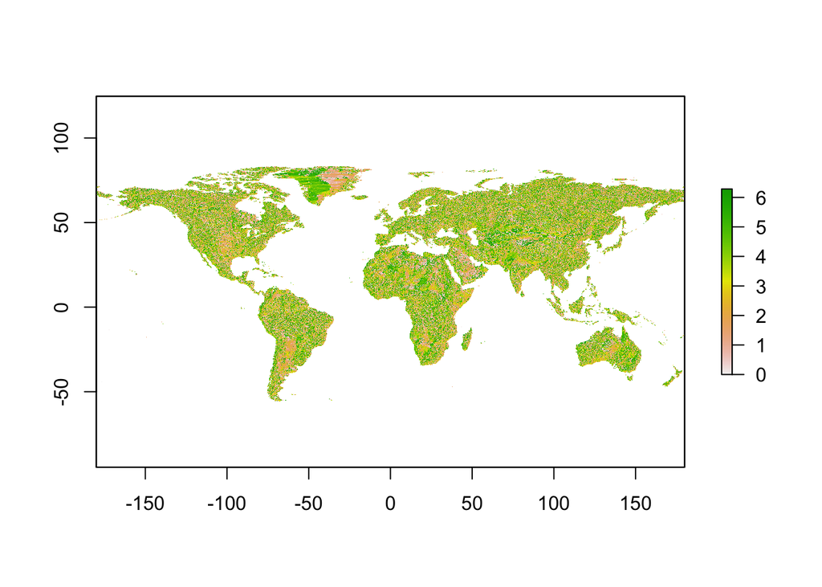

```r
r <- raster("../data/hwsd/2.1/10m/Aspect_10deg.tif", values=T, nrows=900, ncols=2160, xmn=-180, xmx=180, ymn=-60, ymx=60)
plot(r)
```

### Slope

Slope is the percent change in elevation over a certain distance. This is high in rugged mountains.

```r
GDALinfo("../data/hwsd/2.1/10m/slope_10deg.tif")
```

```
## rows        900
## columns     2160
## bands       1
## lower left origin.x        -180
## lower left origin.y        -60
## res.x       0.1666667
## res.y       0.1666667
## ysign       -1
## oblique.x   0
## oblique.y   0
## driver      GTiff
## projection  +proj=longlat +datum=WGS84 +no_defs
## file        ../data/hwsd/2.1/10m/slope_10deg.tif
## apparent band summary:
##    GDType hasNoDataValue NoDataValue blockSize1 blockSize2
## 1 Float32           TRUE    -3.4e+38          1       2160
## apparent band statistics:
##   Bmin      Bmax      Bmean        Bsd
## 1    0 0.5008034 0.01514465 0.02426357
## Metadata:
## AREA_OR_POINT=Area
```

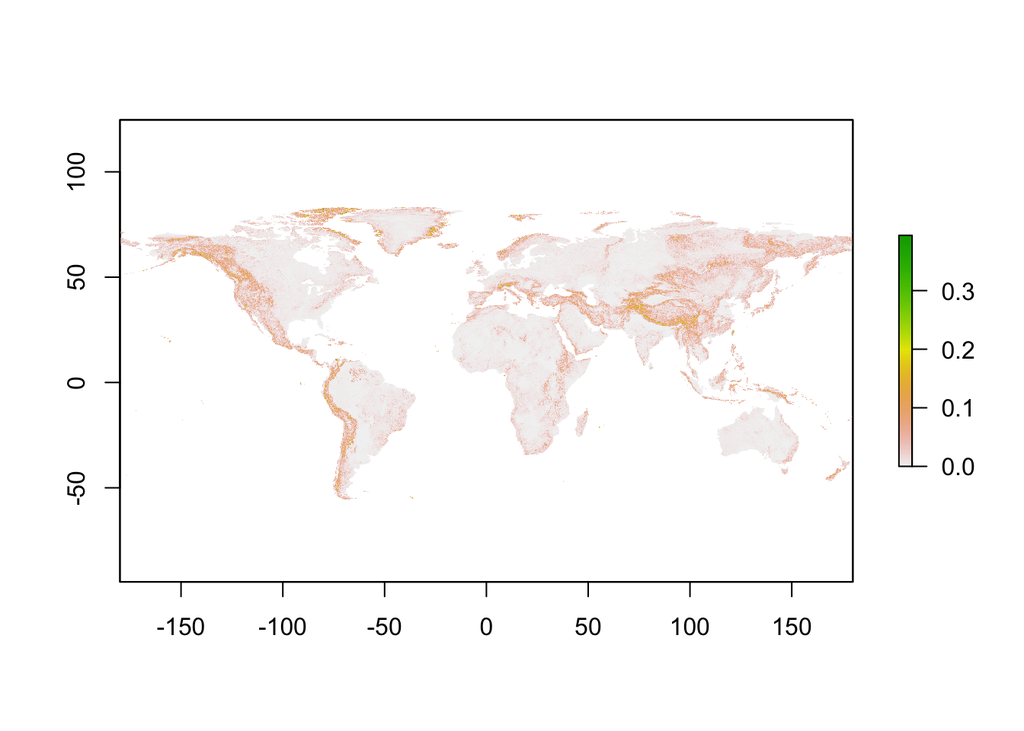

```r
r <- raster("../data/hwsd/2.1/10m/slope_10deg.tif", values=T, nrows=900, ncols=2160, xmn=-180, xmx=180, ymn=-60, ymx=60)
plot(r)
```